# Global Income Mobility Analysis (2003-2023) - Relative GDP

Mashhood Raza Khan

2025-07-09

# Introduction

# Data Fetching and Preparation

## Fetching GDP Data

GDP per capita (PPP, current international $) data is fetched for all available countries for the years 2003 and 2023 from the World Bank.

```r
gdp_data <- WDI(
  country = "all",
  indicator = "NY.GDP.PCAP.PP.CD",
  start = 2003,
  end = 2023,
  extra = FALSE,
  cache = NULL
)
```

## Cleaning and Initial Filtering

The fetched data is cleaned by renaming columns and removing entries with missing GDP values.

```r
gdp_data <- gdp_data %>%
  rename(
    CountryName = country,
    Year = year,
    Value = NY.GDP.PCAP.PP.CD
  ) %>%
  filter(!is.na(Value))
```

## Selecting 100 Countries

The analysis focuses on the 100 countries based on their GDP per capita in 2023 to ensure a consistent and relevant set of nations.

```r
top_100 <- gdp_data %>%
  filter(Year == 2023) %>%
  arrange(desc(Value)) %>%
  slice_head(n = 100) %>%
  pull(CountryName)

# Selecting countries only if they have data for both 2003 and 2023 for the selected top 100.
data_top100 <- gdp_data %>%
  filter(CountryName %in% top_100, Year %in% c(2003, 2023))
```

### Raw GDP Data for Selected Countries (2003 & 2023)

```r
gdp_wide <- data_top100 %>%
  pivot_wider(names_from = Year, values_from = Value, names_prefix = "GDP_") %>%
  arrange(CountryName) # Sorting by country name

# Displaying the data
gdp_wide_sample <- gdp_wide

# Rendering the table using kable.
kable(gdp_wide_sample, caption = "Sample of GDP per Capita (PPP) for Selected Countries (2003 & 2023)") %>%
  kable_styling(bootstrap_options = c("striped", "hover", "condensed"), full_width = FALSE) %>%
  scroll_box(width = "100%", height = "300px")
```

Sample of GDP per Capita (PPP) for Selected Countries (2003 & 2023)

| CountryName | iso2c | iso3c | GDP_2023 | GDP_2003 |
| --- | --- | --- | --- | --- |
| Andorra | AD | AND | 71730.67 | 41147.881 |
| Antigua and Barbuda | AG | ATG | 31601.75 | 20127.346 |
| Argentina | AR | ARG | 30082.30 | 10933.393 |
| Aruba | AW | ABW | 44967.34 | 32507.084 |
| Australia | AU | AUS | 70513.47 | 30121.818 |
| Austria | AT | AUT | 70478.79 | 31962.926 |
| Azerbaijan | AZ | AZE | 23651.60 | 4718.421 |
| Bahamas, The | BS | BHS | 39090.17 | 27030.875 |
| Bahrain | BH | BHR | 64171.09 | 45426.935 |
| Belarus | BY | BLR | 30834.18 | 7361.722 |
| Belgium | BE | BEL | 69059.18 | 30934.583 |
| Bermuda | BM | BMU | 114372.05 | 61829.324 |
| Brunei Darussalam | BN | BRN | 85032.60 | 79632.172 |
| Bulgaria | BG | BGR | 37501.74 | 8417.471 |
| Canada | CA | CAN | 64462.92 | 32351.546 |
| Caribbean small states | S3 | CSS | 32739.20 | 13863.196 |
| Cayman Islands | KY | CYM | 86689.21 | NA |
| Central Europe and the Baltics | B8 | CEB | 46523.72 | 12342.172 |
| Chile | CL | CHL | 32801.38 | 10708.824 |
| China | CN | CHN | 25179.12 | 4007.116 |
| Costa Rica | CR | CRI | 28075.14 | 8862.994 |
| Croatia | HR | HRV | 45595.62 | 13693.289 |
| Curacao | CW | CUW | 30715.57 | 23522.275 |
| Cyprus | CY | CYP | 57204.59 | 24281.111 |
| Czechia | CZ | CZE | 53217.22 | 19606.589 |
| Denmark | DK | DNK | 73737.45 | 30868.046 |
| Dominican Republic | DO | DOM | 25839.94 | 7097.557 |
| East Asia & Pacific | Z4 | EAS | 25448.22 | 6913.130 |
| Estonia | EE | EST | 46790.27 | 13136.719 |
| Euro area | XC | EMU | 61462.68 | 27856.585 |

[output cut: 70 more lines]

*(Note: Only 96 countries were considered as complete data of 4 countries were missing)*

## Assigning Income Quartile Groups (Relative to Average GDP)

Countries are now assigned to one of four income groups (quartiles) based on their GDP per capita **relative to the average GDP of the selected countries in that specific year**. This highlights their position within the group.

```r
data_top100 <- data_top100 %>%
  group_by(Year) %>%
  mutate(
    AvgGDP_Year = mean(Value, na.rm = TRUE), # Calculate average GDP for the year
    RelativeGDP = Value / AvgGDP_Year,       # Calculate relative GDP
    IncomeGroup = ntile(RelativeGDP, 4),     # Divide into 4 quartiles based on relative GDP
    IncomeGroup = case_when(
      IncomeGroup == 1 ~ "¼",      # Lowest 25% relative to average
      IncomeGroup == 2 ~ "½",      # 25% - 50% relative to average
      IncomeGroup == 3 ~ "1",      # 50% - 75% relative to average
      IncomeGroup == 4 ~ "2"       # Top 25% relative to average
    )
  ) %>%
  ungroup()
```

## Preparing Mobility Data

The income groups for 2003 and 2023 are combined to create a dataset showing the transition of each of the 96 countries.

```r
group_2003 <- data_top100 %>%
  filter(Year == 2003) %>%
  select(CountryName, Group2003 = IncomeGroup)

group_2023 <- data_top100 %>%
  filter(Year == 2023) %>%
  select(CountryName, Group2023 = IncomeGroup)

mobility_data <- inner_join(group_2003, group_2023, by = "CountryName")
```

### Country Income Group Transitions

This table shows which income quartile (relative to average GDP) each country belonged to in 2003 and 2023.

```r
# Displaying the mobility data
mobility_data_sample <- mobility_data

kable(mobility_data_sample, caption = "Sample of Country Income Group Transitions (2003 to 2023) - Relative GDP") %>%
  kable_styling(bootstrap_options = c("striped", "hover", "condensed"), full_width = FALSE) %>%
  scroll_box(width = "100%", height = "300px")
```

Sample of Country Income Group Transitions (2003 to 2023) - Relative GDP

| CountryName | Group2003 | Group2023 |
| --- | --- | --- |
| Caribbean small states | ½ | ¼ |
| Central Europe and the Baltics | ½ | ½ |
| East Asia & Pacific | ¼ | ¼ |
| Euro area | 1 | 1 |
| Europe & Central Asia | ½ | ½ |
| Europe & Central Asia (excluding high income) | ¼ | ¼ |
| Europe & Central Asia (IDA & IBRD countries) | ¼ | ½ |
| European Union | 1 | 1 |
| High income | 1 | 1 |
| Late-demographic dividend | ¼ | ¼ |
| North America | 2 | 2 |
| OECD members | 1 | 1 |
| Other small states | ½ | ¼ |
| Post-demographic dividend | 1 | 1 |
| Small states | ½ | ¼ |
| Andorra | 2 | 2 |
| Antigua and Barbuda | ½ | ¼ |
| Argentina | ½ | ¼ |
| Aruba | 2 | ½ |
| Australia | 1 | 2 |
| Austria | 2 | 2 |
| Azerbaijan | ¼ | ¼ |
| Bahamas, The | 1 | ½ |
| Bahrain | 2 | 1 |
| Belarus | ¼ | ¼ |
| Belgium | 1 | 2 |
| Bermuda | 2 | 2 |
| Brunei Darussalam | 2 | 2 |
| Bulgaria | ¼ | ½ |
| Canada | 2 | 1 |

[output cut: 66 more lines]

# Mobility Matrix Analysis

## Calculating the Mobility Matrix

A contingency table is created to summarize the transitions between income groups based on relative GDP.

```r
mobility_matrix <- table(mobility_data$Group2003, mobility_data$Group2023)

print("Mobility Matrix (Counts - Relative GDP):")
```

```
## [1] "Mobility Matrix (Counts - Relative GDP):"
```

```r
print(mobility_matrix)
```

```
##
##      ¼  ½  1  2
##   ¼ 15  8  1  0
##   ½  9 11  4  0
##   1  1  3 15  5
##   2  0  2  4 18
```

## Visualizing the Mobility Matrix (Heatmap)

A heatmap provides a clear visual representation of how countries moved between income quartiles based on their relative GDP standing.

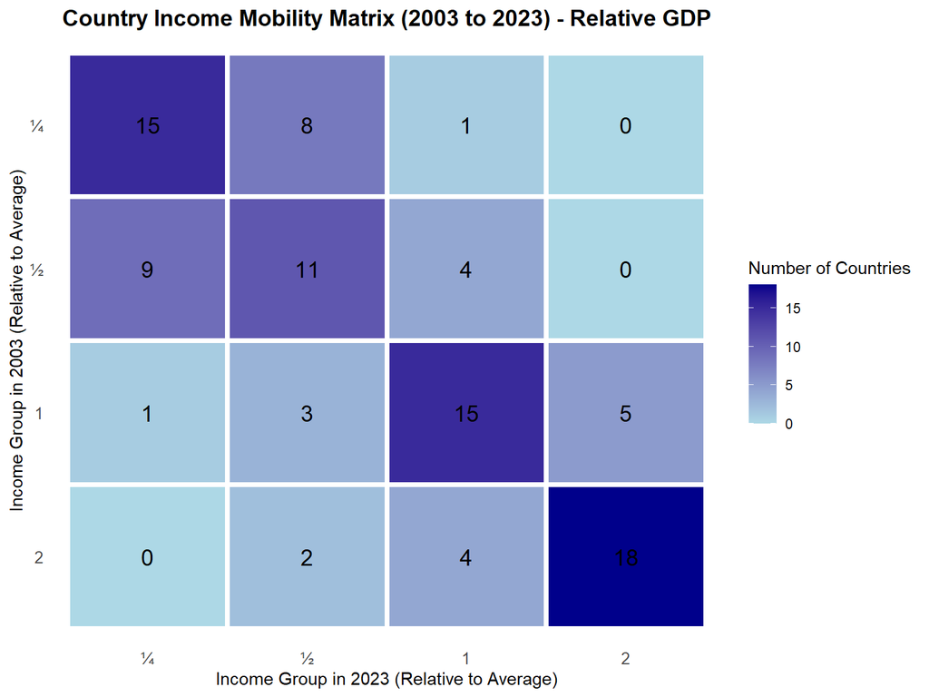

Heatmap of Country Income Mobility (2003 to 2023) - Relative GDP

```r
# Converting the mobility matrix to a data frame for ggplot2.
mobility_matrix_df_plot <- as.data.frame.matrix(mobility_matrix) %>%
  tibble::rownames_to_column("Group2003") %>%
  tidyr::pivot_longer(
    cols = c("¼", "½", "1", "2"), # Explicitly selecting the quartile columns
    names_to = "Group2023",
    values_to = "Count"
  )

# Defining order of quartile labels
quartile_order <- c("¼", "½", "1", "2")

# Converting Group2003 and Group2023 to factors with the desired order
mobility_matrix_df_plot$Group2003 <- factor(mobility_matrix_df_plot$Group2003, levels = quartile_order)
mobility_matrix_df_plot$Group2023 <- factor(mobility_matrix_df_plot$Group2023, levels = quartile_order)

# Creating the heatmap using ggplot2
ggplot(mobility_matrix_df_plot, aes(x = Group2023, y = Group2003, fill = Count)) +
  geom_tile(color = "white", linewidth = 1.5) +
  geom_text(aes(label = Count), color = "black", size = 5) +
  scale_fill_gradient(low = "lightblue", high = "darkblue", name = "Number of Countries") +

  scale_x_discrete(limits = quartile_order) +
  scale_y_discrete(limits = rev(quartile_order)) +
  labs(
    title = "Country Income Mobility Matrix (2003 to 2023) - Relative GDP",
    x = "Income Group in 2023 (Relative to Average)",
    y = "Income Group in 2003 (Relative to Average)"
  ) +
  theme_minimal() +
  theme(
    plot.title = element_text(hjust = 0.5, face = "bold", size = 14),
    axis.title = element_text(size = 11),
    axis.text = element_text(size = 10),
    legend.position = "right",
    panel.grid.major = element_blank(),
    panel.grid.minor = element_blank()
  )
```

# Conclusion

This report provides an overview of how countries’ income groups (based on GDP per capita PPP relative to the group average) have shifted between 2003 and 2023. The heatmap visually summarizes the relative mobility, showing where countries originated in 2003 and where they ended up in 2023 within the context of the 96 countries.